# ppatil8_hw5

```r
prune.carseats <- prune.misclass(tree.carseats, best = 9)
plot(prune.carseats)
text(prune.carseats, pretty = 0)
tree.pred <- predict(prune.carseats, Carseats.test, type = "class")
table(tree.pred, High.test)
```

```
##          High.test
## tree.pred No Yes
##       No  97  25
##       Yes 20  58
```

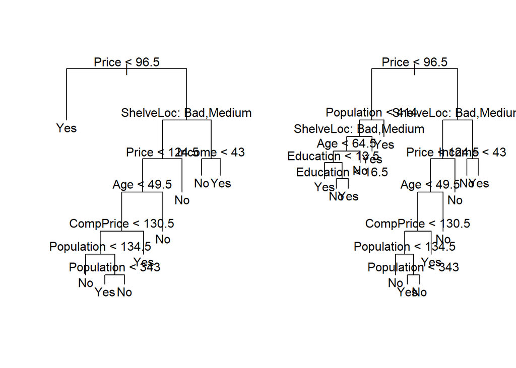

```r
prune.carseats <- prune.misclass(tree.carseats, best = 14)
plot(prune.carseats)
text(prune.carseats, pretty = 0)
```

```r
tree.pred <- predict(prune.carseats, Carseats.test, type = "class")
table(tree.pred, High.test)
```

```
##          High.test
## tree.pred  No Yes
##       No  102  31
##       Yes  15  52
```

##Lab 8.3.2 Fitting Regression Trees

```r
set.seed(1)
train <- sample(1:nrow(Boston), nrow(Boston) / 2)
tree.boston <- tree(medv ~., Boston, subset = train)
summary(tree.boston)
```

```
##
## Regression tree:
## tree(formula = medv ~ ., data = Boston, subset = train)
## Variables actually used in tree construction:
## [1] "rm"    "lstat" "crim"  "age"
## Number of terminal nodes:  7
## Residual mean deviance:  10.38 = 2555 / 246
## Distribution of residuals:
##     Min.  1st Qu.   Median     Mean  3rd Qu.     Max.
## -10.1800  -1.7770  -0.1775   0.0000   1.9230  16.5800
```

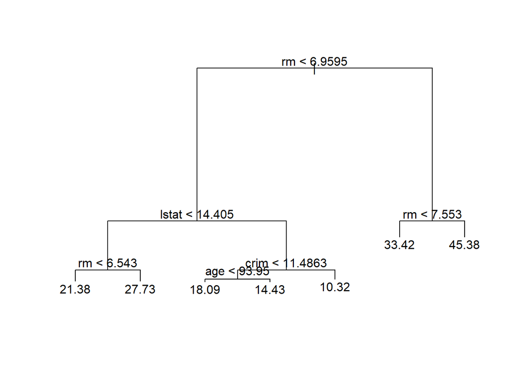

```r
plot(tree.boston)
text(tree.boston, pretty = 0)
```

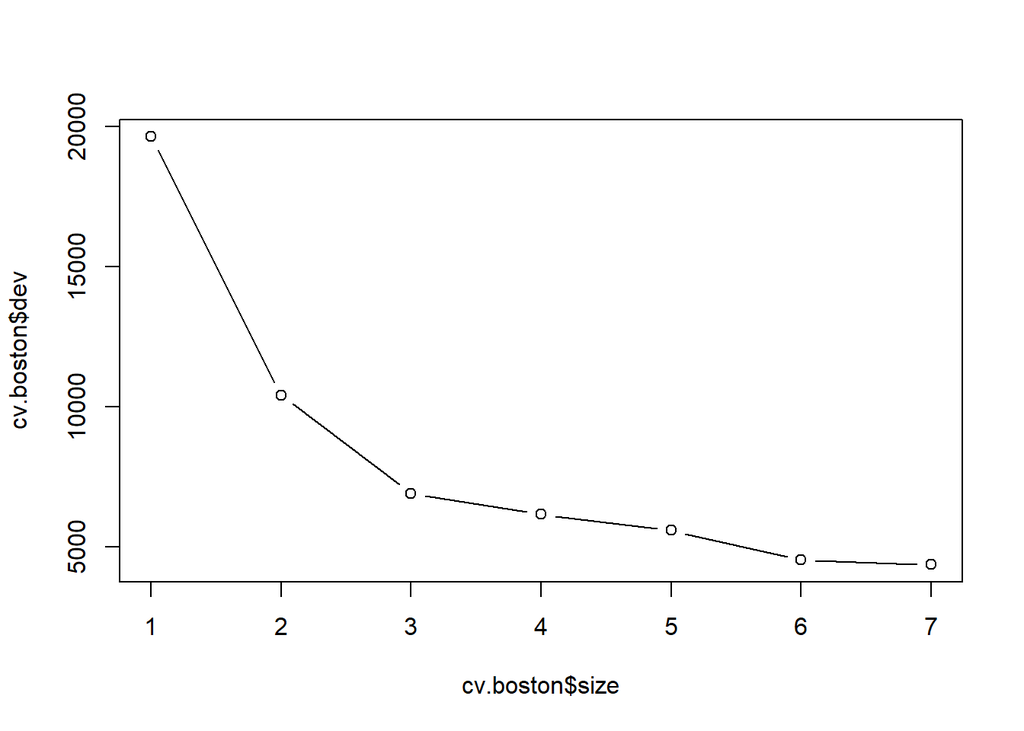

```r
cv.boston <- cv.tree(tree.boston)
plot(cv.boston$size, cv.boston$dev, type = "b")
```

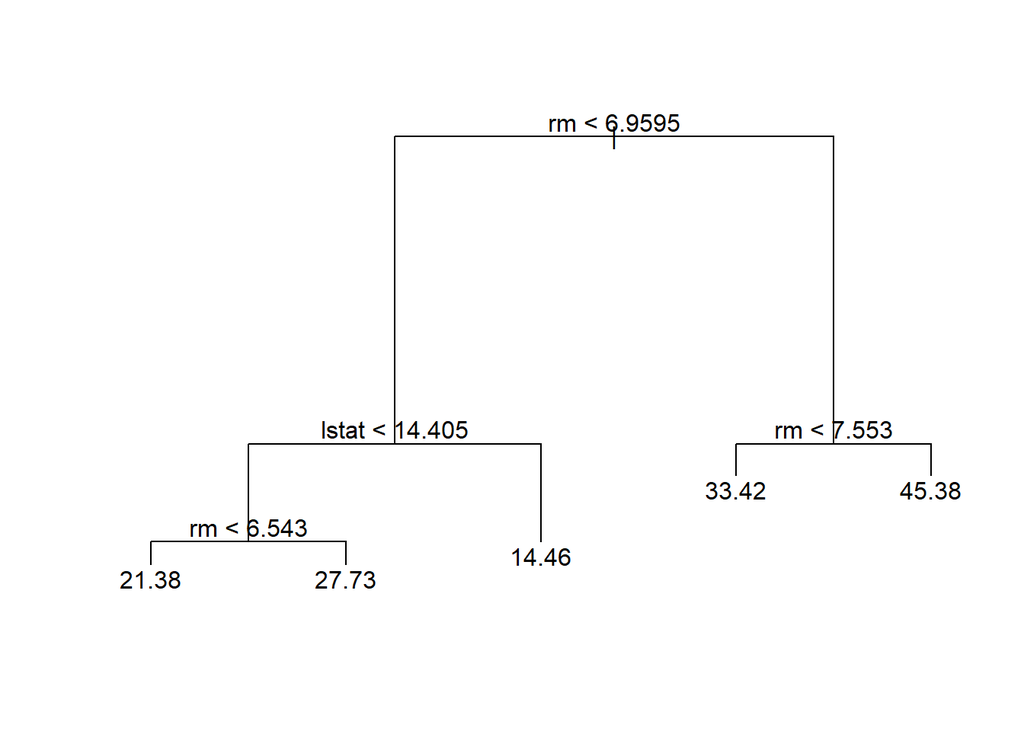

```r
prune.boston <- prune.tree(tree.boston, best = 5)
plot(prune.boston)
text(prune.boston, pretty = 0)
```

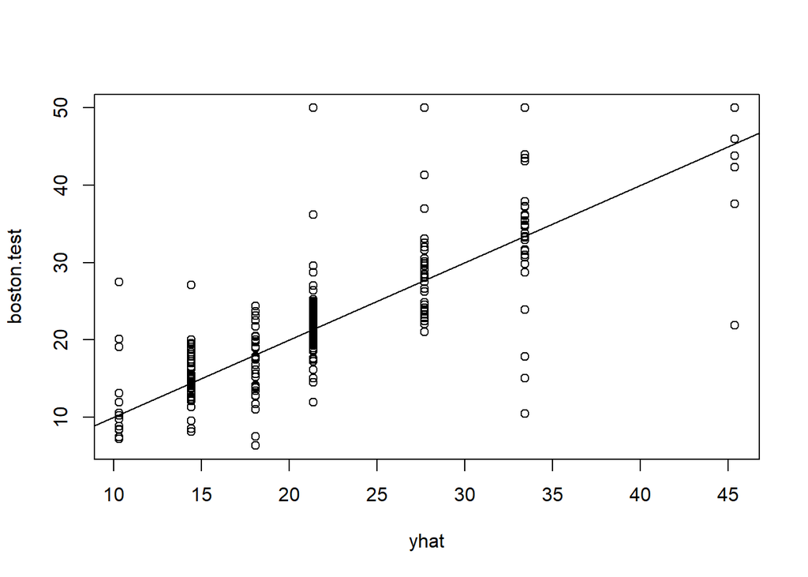

```r
yhat <- predict(tree.boston, newdata = Boston[-train, ])
boston.test <- Boston[-train, "medv"]
plot(yhat, boston.test)
abline(0, 1)
```

```r
mean((yhat - boston.test)^2)
```

```
## [1] 35.28688
```

#Lab 8.3.3 Bagging and Random Forests

```r
library(randomForest)
set.seed(1)
bag.boston <- randomForest(medv ~., data = Boston, subset = train, mtry = 12, importance = TRUE)
bag.boston
```

```
##
## Call:
##  randomForest(formula = medv ~ ., data = Boston, mtry = 12, importance = TRUE,      subset = train)
##                Type of random forest: regression
##                      Number of trees: 500
## No. of variables tried at each split: 12
##
##           Mean of squared residuals: 11.40162
##                     % Var explained: 85.17
```

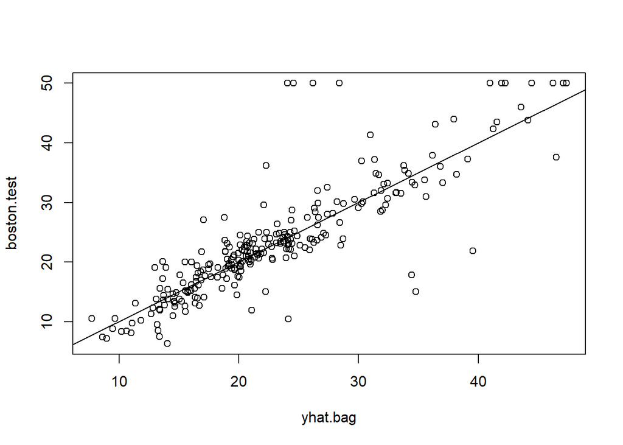

```r
yhat.bag <- predict(bag.boston, newdata = Boston[-train, ])
plot(yhat.bag, boston.test)
abline(0, 1)
```

```r
mean((yhat.bag - boston.test)^2)
```

```
## [1] 23.41916
```

```r
bag.boston <- randomForest(medv ~., data = Boston, subset = train, mtry = 12, ntree = 25)
yhat.bag <- predict(bag.boston, newdata = Boston[-train, ])
mean((yhat.bag - boston.test)^2)
```

```
## [1] 25.75055
```

```r
set.seed(1)
rf.boston <- randomForest(medv ~., data = Boston, subset = train, mtry = 6, importance = TRUE)
yhat.rf <- predict(rf.boston, newdata = Boston[-train, ])
mean((yhat.rf - boston.test)^2)
```

```
## [1] 20.06644
```

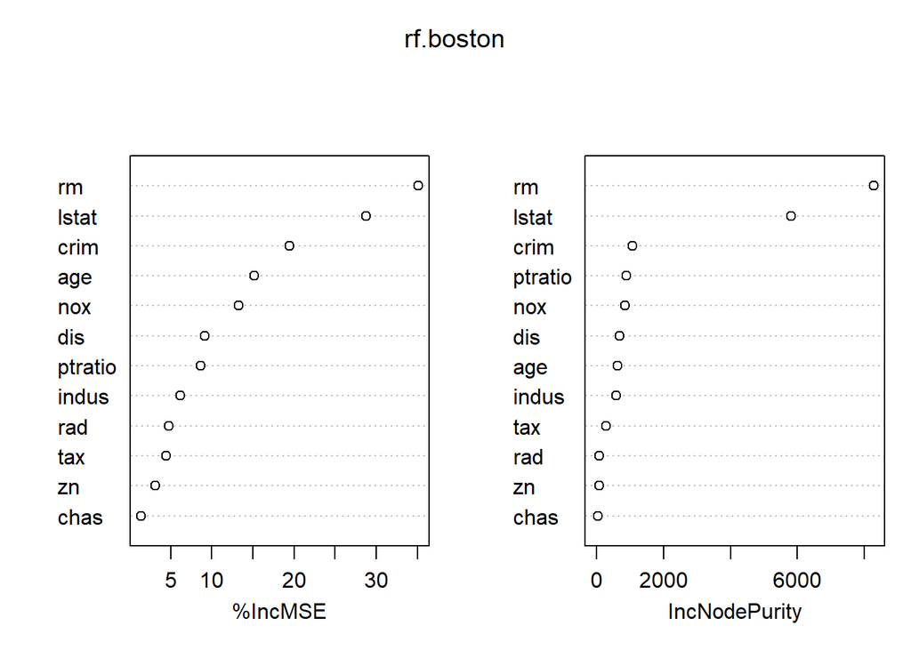

```r
varImpPlot(rf.boston)
```

#Lab 8.3.4 Boosting

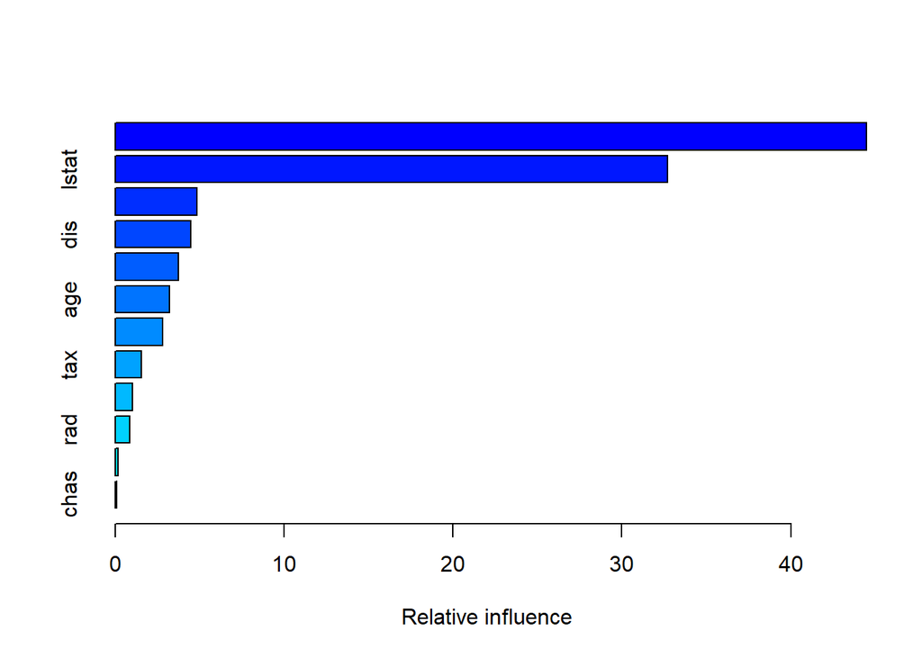

```
##             var     rel.inf
## rm           rm 44.48249588
## lstat     lstat 32.70281223
## crim       crim  4.85109954
## dis         dis  4.48693083
## nox         nox  3.75222394
## age         age  3.19769210
## ptratio ptratio  2.81354826
## tax         tax  1.54417603
## indus     indus  1.03384666
## rad         rad  0.87625748
## zn           zn  0.16220479
## chas       chas  0.09671228
```

```r
library(gbm)
set.seed(1)
boost.boston <- gbm(medv ~., data = Boston[train, ], distribution = "gaussian", n.trees = 5000, interaction.dept = 4)
summary(boost.boston)
```

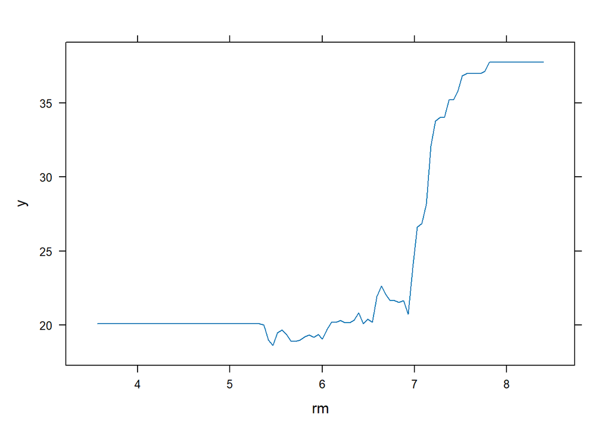

```r
plot(boost.boston, i = "rm")
```

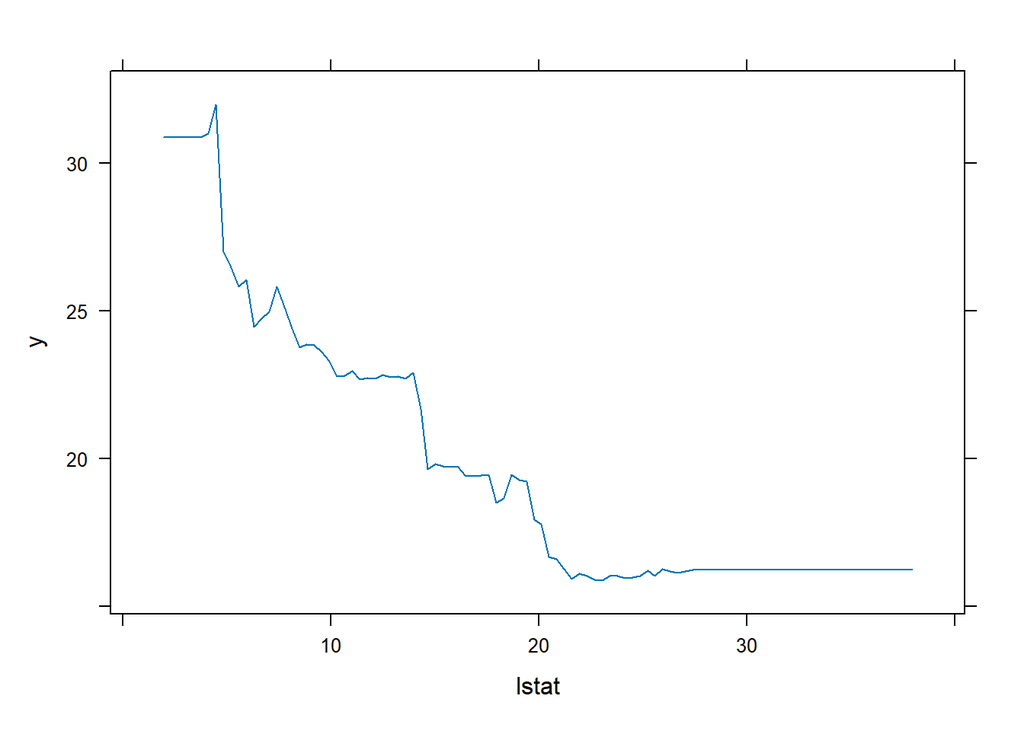

```r
plot(boost.boston, i = "lstat")
```

```r
yhat.boost <- predict(boost.boston, newdata = Boston[-train, ], n.trees = 5000)
mean((yhat.boost - boston.test)^2)
```

```
## [1] 18.39057
```

```r
boost.boston <- gbm(medv ~., data = Boston[train, ], distribution = "gaussian", n.trees = 5000, interaction.depth = 4, shrinkage = 0.2, verbose = F)
yhat.boost <- predict(boost.boston, newdata = Boston[-train, ], n.trees = 5000)
mean((yhat.boost - boston.test)^2)
```

```
## [1] 16.54778
```

#Lab 8.3.5 Bayesian Additive Regression Trees

```r
library(BART)
x <- Boston[, 1:12]
y <- Boston[, "medv"]
xtrain <- x[train, ]
ytrain <- y[train]
xtest <- x[-train, ]
ytest <- y[-train]
set.seed(1)
bartfit <- gbart(xtrain, ytrain, x.test = xtest)
```

[output not shown]

```r
yhat.bart <- bartfit$yhat.test.mean
mean((ytest - yhat.bart)^2)
```

```
## [1] 15.94718
```

```r
ord <- order(bartfit$varcount.mean, decreasing = T)
bartfit$varcount.mean[ord]
```

```
##     nox   lstat     tax     rad      rm   indus    chas ptratio     age      zn
##  22.952  21.329  21.250  20.781  19.890  19.825  19.051  18.976  18.274  15.952
##     dis    crim
##  14.457  11.007
```

########Exercise########

##Exercise 8.4

#Q.8.4.7

```r
library(ISLR2)
library(randomForest)
library(tree)
attach(Wage)
attach(Carseats)
library(caTools)
```

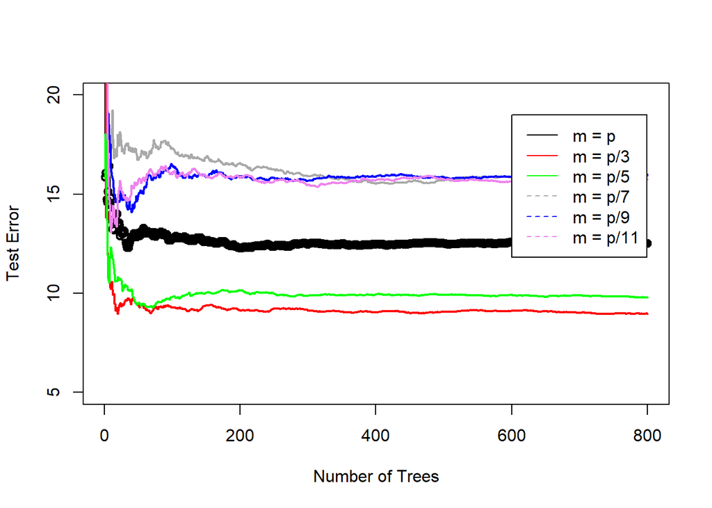

```r
set.seed(1)
Boston = Boston
sample.data = sample.split(Boston$medv, SplitRatio = 0.70)
train.set = subset(Boston, select =-c(medv), sample.data == TRUE)
test.set = subset(Boston, select =-c(medv), sample.data == FALSE)
train.Y = subset(Boston$medv, sample.data == TRUE)
test.Y = subset(Boston$medv, sample.data == FALSE)

p = 10
Tree1 = randomForest(train.set, train.Y, test.set, test.Y, mtry = p, ntree = 800)
Tree2 = randomForest(train.set, train.Y, test.set, test.Y, mtry = p/3, ntree = 800)
Tree3 = randomForest(train.set, train.Y, test.set, test.Y, mtry = p/5, ntree = 800)
Tree4 = randomForest(train.set, train.Y, test.set, test.Y, mtry = p/7, ntree = 800)
Tree5 = randomForest(train.set, train.Y, test.set, test.Y, mtry = p/9, ntree = 800)
Tree6 = randomForest(train.set, train.Y, test.set, test.Y, mtry = p/10, ntree = 800)

x.axis = seq(1, 800, 1)
plot(x.axis, Tree1$test$mse, xlab = "Number of Trees", ylab = "Test Error", ylim = c(5, 20),type ="b",lwd = 2)
lines(x.axis, Tree2$test$mse, col = "red", lwd = 2)
lines(x.axis, Tree3$test$mse, col = "green", lwd = 2)
lines(x.axis, Tree4$test$mse, col = "darkgrey", lwd = 2)
lines(x.axis, Tree5$test$mse, col = "blue", lwd = 2)
lines(x.axis, Tree6$test$mse, col = "violet", lwd = 2)
legend(600, 19, legend = c("m = p", "m = p/3", "m = p/5", "m = p/7", "m = p/9", "m = p/11"),
       col = c("black", "red", "green", "darkgrey", "blue", "violet"), lty = c(1,1,1, lwd = c(2,2,2)))
```

#The test error rate decreases initially from m = p to m = p/5 and then it increases from m = p/7 to p/10

#The test error rate decreases rapidly with the icrease in number of trees

#While the change in test error rate follows a similar pattern from m = p to m = p/3, remaining values of m follws a similar pattern where a slight spike is seen around number of trees = 50=150 and it becomes constant after that

#Q.8.4.8

##a

```r
set.seed(5)
train_index <- sample(1:nrow(Carseats), nrow(Carseats) / 2)
train <- Carseats[train_index, ]
test <- Carseats[-train_index, ]
```

##b

```r
tree_model <- tree(Sales ~ .,train)
plot(tree_model)
summary(tree_model)
```

```
##
## Regression tree:
## tree(formula = Sales ~ ., data = train)
## Variables actually used in tree construction:
## [1] "High"        "ShelveLoc"   "Price"       "Income"      "Advertising"
## [6] "CompPrice"
## Number of terminal nodes:  10
## Residual mean deviance:  1.779 = 338.1 / 190
## Distribution of residuals:
##     Min.  1st Qu.   Median     Mean  3rd Qu.     Max.
## -4.73800 -0.89780 -0.01799  0.00000  0.99220  3.77100
```

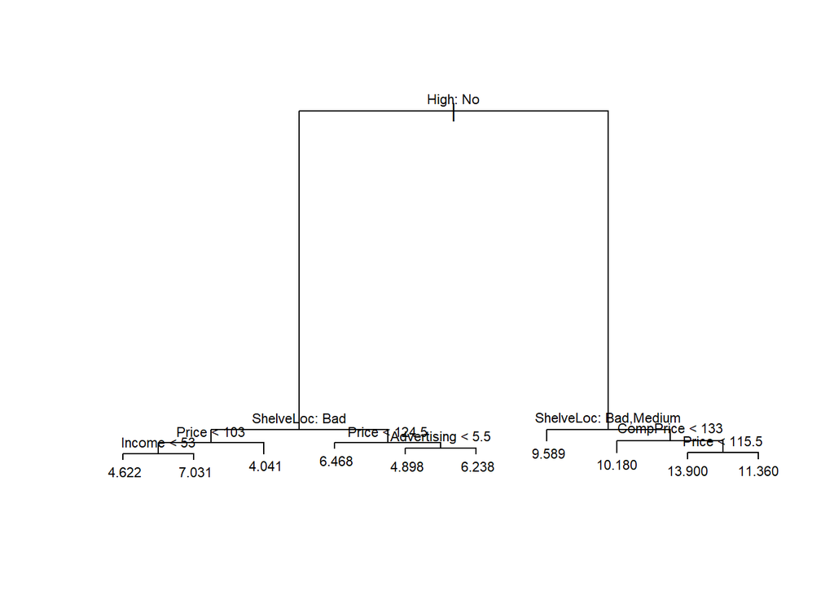

```r
text(tree_model, pretty = 0, cex = 0.7)
```

```r
test_pred <- predict(tree_model, test)
mean((test_pred - test$Sales)^2)
```

```
## [1] 2.673161
```

```r
baseline<- mean(train$Sales)
mean((baseline- test$Sales)^2)
```

```
## [1] 7.770407
```

##c

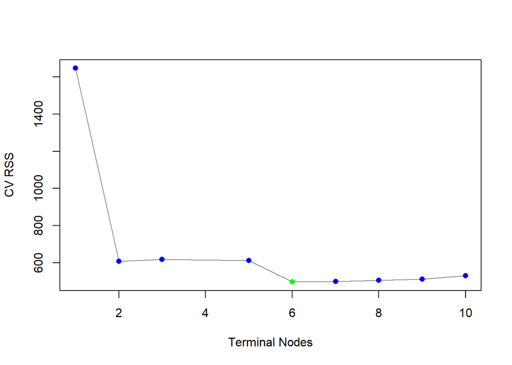

```r
set.seed(2)
cv_tree_model <- cv.tree(tree_model, K = 10)
df <- data.frame(n_leaves = cv_tree_model$size,
                 CV_RSS = cv_tree_model$dev)
df$min_CV_RSS <- as.numeric(df$CV_RSS == min(df$CV_RSS))
plot(df$n_leaves, df$CV_RSS, type = "l", col = "grey55", xlab = "Terminal Nodes", ylab = "CV RSS")
points(df$n_leaves[df$min_CV_RSS == 1], df$CV_RSS[df$min_CV_RSS == 1], col = "green", pch = 16)
points(df$n_leaves[df$min_CV_RSS == 0], df$CV_RSS[df$min_CV_RSS == 0], col = "blue", pch = 16)
```

```r
pruned_tree_model <- prune.tree(tree_model, best = 6)
test_pred <- predict(pruned_tree_model, test)
mean((test_pred - test$Sales)^2)
```

```
## [1] 2.657053
```

```r
data.frame(size = cv_tree_model$size,
           dev = cv_tree_model$dev,
           k = cv_tree_model$k)
```

```
##   size       dev          k
## 1   10  531.4085       -Inf
## 2    9  512.3406   18.14491
## 3    8  506.9427   19.01082
## 4    7  500.9913   19.90660
## 5    6  497.6567   20.73729
## 6    5  611.9798   35.76353
## 7    3  618.4408   37.72239
## 8    2  607.5326   43.88306
## 9    1 1646.1257 1062.45111
```

#CV Error is lowest for tree with 6 nodes

#The full tree is pruned to obtain 6 node tree

#The test MSE reduces for pruned tree

##d

```r
set.seed(7)
bagged = randomForest(y = train$Sales,x = train[ ,-1],mtry=ncol(train)-1,importance=TRUE)
test_pred <- predict(bagged, test)
importance(bagged)
```

```
##               %IncMSE IncNodePurity
## CompPrice   14.132694     95.202527
## Income       6.400759     62.227943
## Advertising  5.335336     44.138343
## Population  -2.867007     40.317799
## Price       20.391073    105.294905
## ShelveLoc   21.606995     90.946914
## Age          1.488669     56.319208
## Education    2.130281     40.082096
## Urban       -1.436525      5.127913
## US           3.868317      4.682842
## High        85.029815   1056.186420
```

```r
mean((test_pred-test$Sales)^2)
```

```
## [1] 2.178019
```

#Test MSE is 2.178019

#Bagging has slightly improved Test MSE

##e

```r
set.seed(2)
rf1.carseats = randomForest(Sales~.,data=train,mtry=7/5,importance=T)
rf2.carseats = randomForest(Sales~.,data=train,mtry=7/3,importance=T)
rf3.carseats = randomForest(Sales~.,data=train,mtry=sqrt(7),importance=T)
rf4.carseats = randomForest(Sales~.,data=train,mtry=7/2,importance=T)
importance(rf1.carseats)
```

```
##                %IncMSE IncNodePurity
## CompPrice    6.8672474     106.94179
## Income       3.9690827      94.15010
## Advertising  7.7052928      82.46877
## Population  -2.6805982      70.62622
## Price       13.4634110     140.42810
## ShelveLoc   19.8001898     178.16816
## Age          6.7595824     100.05118
## Education   -0.2584907      58.22746
## Urban       -2.4995987      18.65480
## US           2.4492590      27.04455
## High        25.5394827     318.53635
```

```r
importance(rf2.carseats)
```

```
##                 %IncMSE IncNodePurity
## CompPrice    7.88947481     119.39522
## Income       2.36144244     106.21746
## Advertising  8.12695826      98.74028
## Population  -2.16603598      74.57968
## Price       15.68408112     173.80236
## ShelveLoc   18.94724850     206.43666
## Age          6.47231373     113.51929
## Education    2.30980615      55.98662
## Urban       -0.06319959      14.70339
## US           2.94585308      19.09368
## High        40.12642189     518.22633
```

```r
importance(rf3.carseats)
```

```
##               %IncMSE IncNodePurity
## CompPrice   10.959707     118.20848
## Income       4.918725     104.97197
## Advertising  5.197411      77.25805
## Population  -2.125292      62.64161
## Price       16.354882     175.01270
## ShelveLoc   20.561178     222.60527
## Age          5.172645      92.63455
## Education    3.197314      53.42319
## Urban       -2.734907      10.44349
## US           1.505688      15.28824
## High        48.400229     628.02620
```

```r
importance(rf4.carseats)
```

```
##               %IncMSE IncNodePurity
## CompPrice   10.732028    108.938023
## Income       4.360848     92.033122
## Advertising  5.146290     74.836207
## Population  -2.309404     50.064860
## Price       15.541719    157.325705
## ShelveLoc   18.872002    209.823541
## Age          5.531277     89.150198
## Education    2.736664     47.057053
## Urban       -2.069024      8.292415
## US           3.725763     10.920554
## High        58.870399    736.946353
```

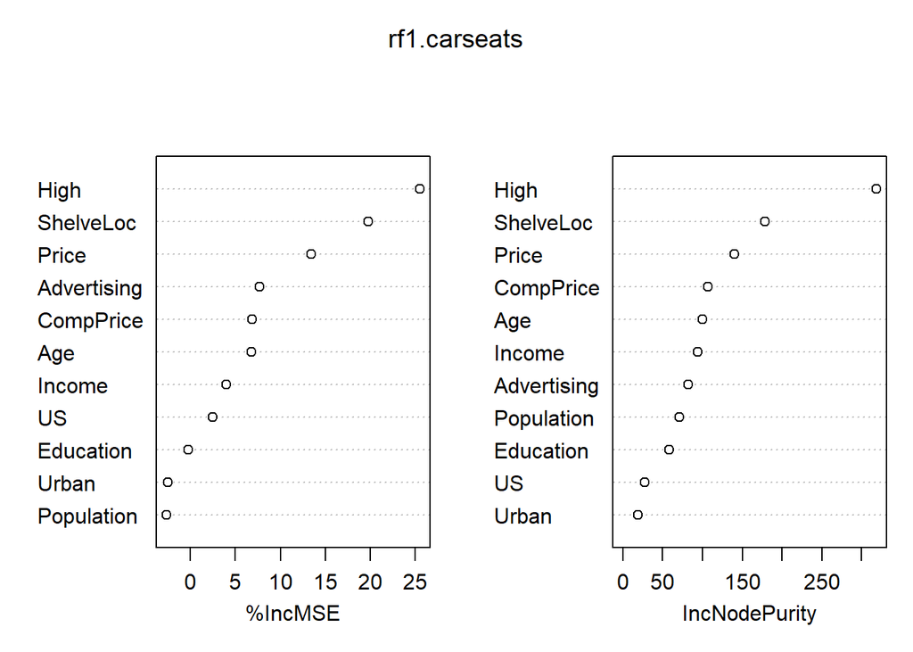

```r
varImpPlot(rf1.carseats)
```

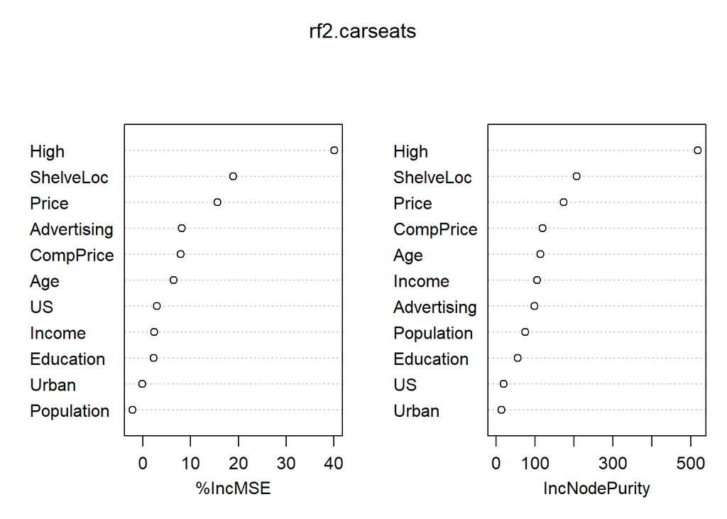

```r
varImpPlot(rf2.carseats)
```

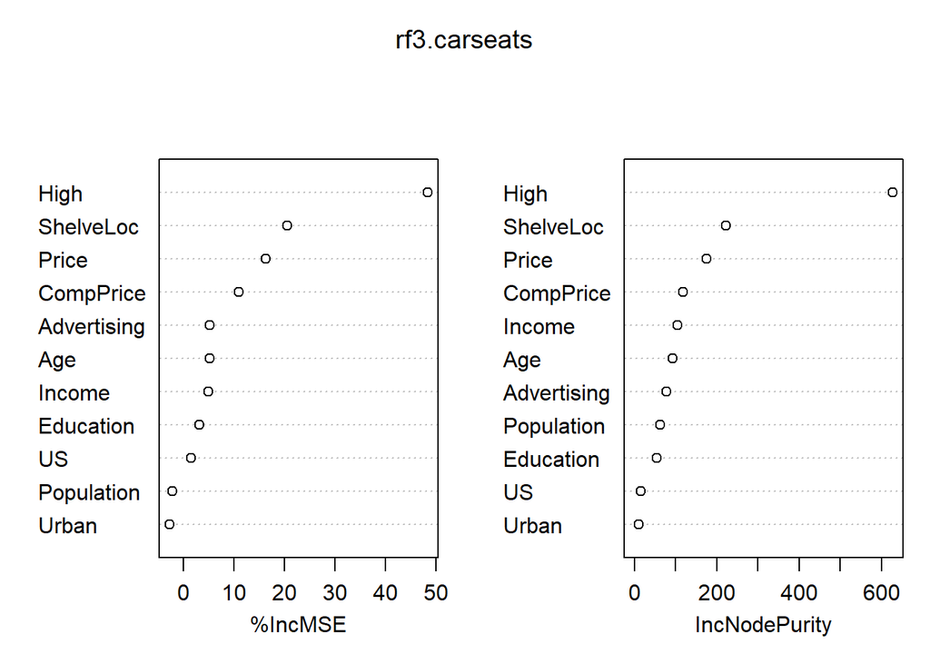

```r
varImpPlot(rf3.carseats)
```

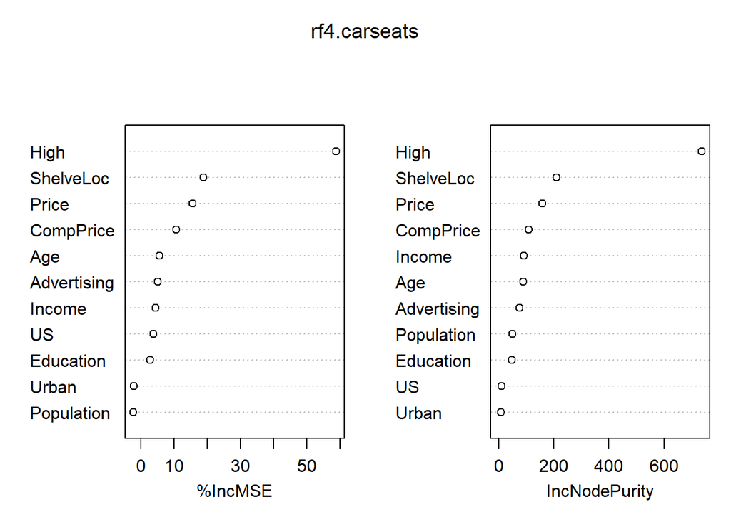

```r
varImpPlot(rf4.carseats)
```

```r
mse1 = mean((predict(rf1.carseats,newdata = test)-test$Sales)^2)
mse2 = mean((predict(rf2.carseats,newdata = test)-test$Sales)^2)
mse3 = mean((predict(rf3.carseats,newdata = test)-test$Sales)^2)
mse4 = mean((predict(rf4.carseats,newdata = test)-test$Sales)^2)
mse1
```

```
## [1] 3.070537
```

```r
mse2
```

```
## [1] 2.162708
```

```r
mse3
```

```
## [1] 2.044368
```

```r
mse4
```

```
## [1] 2.046532
```

#The MSE for some models in random forest is lower than the MSE in Bagging

##f

```r
library(BART)
train <- sample(1:nrow(Carseats), nrow(Carseats) / 2)
x <- Carseats[, 1:11]
y <- Carseats[, "Sales"]
xtrain <- x[train, ]
ytrain <- y[train]
xtest <- x[-train, ]
ytest <- y[-train]
bart_model <- gbart(xtrain, ytrain, x.test = xtest)
```

[output not shown]

```r
yhat.bart <- bart_model$yhat.test.mean
mse_bart <- mean((ytest - bart_model$yhat.test.mean)^2)
mse_bart
```

```
## [1] 0.173918
```

```r
ord <- order(bart_model$varcount.mean, decreasing = TRUE)
bart_model$varcount.mean[ord]
```

```
##       Sales  ShelveLoc2   Education         US2      Urban2       Price
##      28.253      23.496      19.167      16.899      16.743      16.395
##      Urban1         US1  ShelveLoc1  Population         Age  ShelveLoc3
##      13.887      13.668      13.562      12.687      11.174      10.763
##      Income Advertising   CompPrice
##      10.739       8.226       6.277
```

#MSE obtained is 0.173918

#Higher value of BART for variable signifies importance of the predictor varaible

#“ShelveLoc” is highly influential

#Q.8.10

##a

```r
Hitters <- Hitters[!is.na(Hitters$Salary), ]
Hitters$Salary <- log(Hitters$Salary)
```

##b

```r
set.seed(10)
sample.data = sample.split(Hitters$Salary, SplitRatio = 200/263)
train.set = subset(Hitters, sample.data==TRUE)
test.set = subset(Hitters, sample.data==FALSE)
```

##c

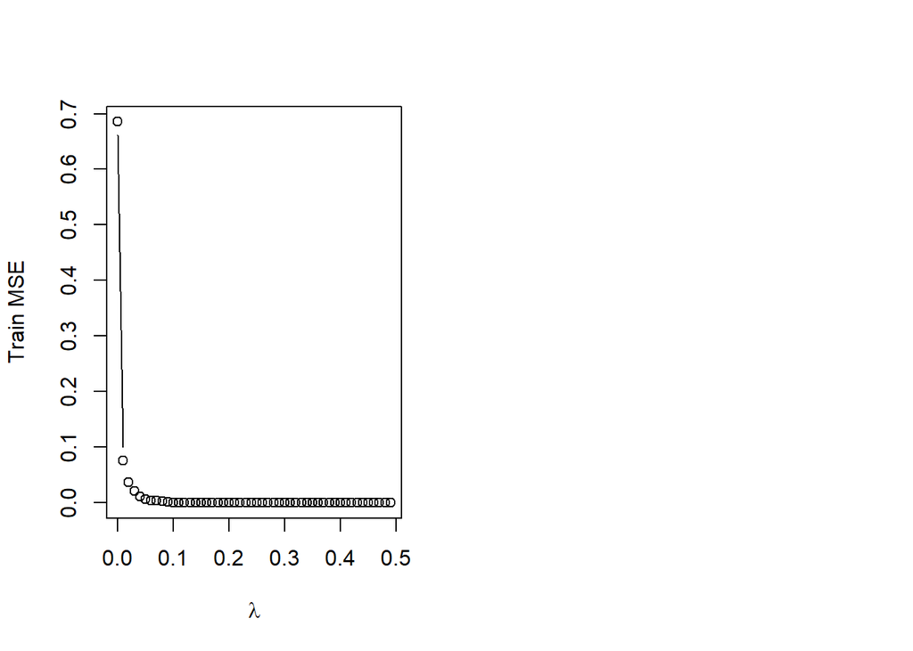

```r
lambdas = seq(0.0001,0.5,0.01)
train.mse = rep(NA,length(lambdas))
test.mse = rep(NA,length(lambdas))

set.seed(4)
for (i in lambdas){
  boost.Hitters = gbm(Salary~., data=train.set,distribution = "gaussian", n.trees = 1000,
                      interaction.depth = 4, shrinkage = i)
  yhat.train = predict(boost.Hitters,newdata = train.set, n.trees = 1000)
  train.mse[which(i==lambdas)] = mean((yhat.train-train.set$Salary)^2)

  yhat.test = predict(boost.Hitters,newdata = test.set, n.trees = 1000)
  test.mse[which(i==lambdas)] = mean((yhat.test-test.set$Salary)^2)
}
par(mfrow=c(1,2))
plot(lambdas,train.mse,type="b",xlab=expression(lambda), ylab="Train MSE")
```

#Train MSE decreases rapidly from lambda = 0 to 0.1. After that train MSE approaches zero from larger values of lambda

##d

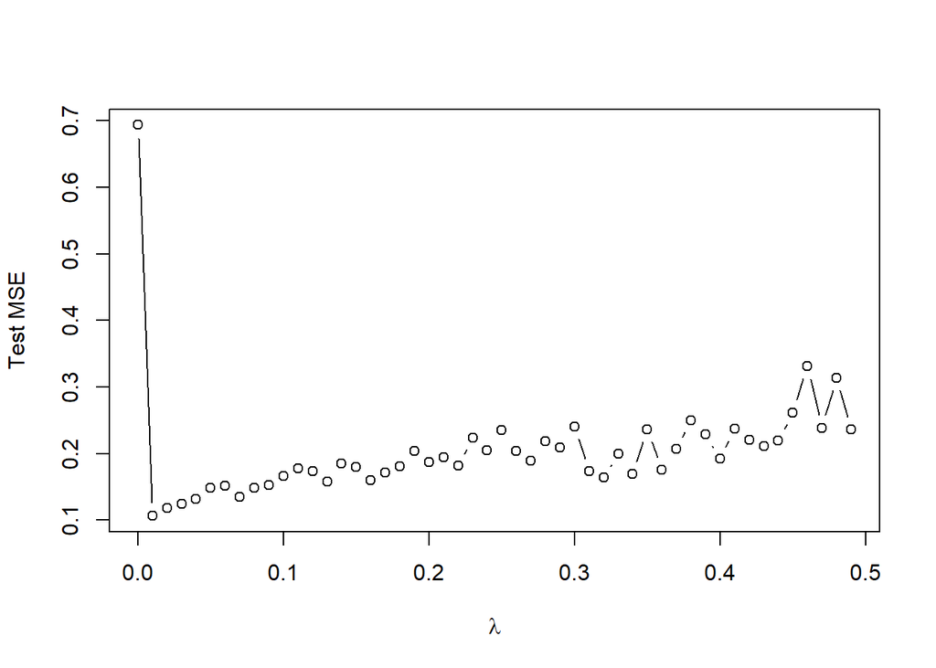

```r
plot(lambdas,test.mse,type="b",xlab=expression(lambda), ylab="Test MSE")
```

```r
lambdas[which.min(test.mse)];min(test.mse)
```

```
## [1] 0.0101
```

```
## [1] 0.1063836
```

```r
lambdas[which.min(train.mse)];min(train.mse)
```

```
## [1] 0.4801
```

```
## [1] 9.621108e-11
```

#After lambda = 0.3, test MSE follows a zig-zag pattern

##e

#Multiple Linear Regression

```r
lm.fit = lm(Salary~., data=train.set)
lm.preds = predict(lm.fit, newdata = test.set)
lm.mse = mean((test.set$Salary-lm.preds)^2)
lm.mse
```

```
## [1] 0.3294574
```

#Lasso Model

```r
library(glmnet)
train = model.matrix(Salary~.,train.set)
test = model.matrix(Salary~.,test.set)
y.train = train.set$Salary
lasso.mod = glmnet(train, y.train, alpha = 1)
set.seed(4)
cv.out=cv.glmnet(train, y.train, alpha=1)
bestlam=cv.out$lambda.min
lasso.pred=predict(lasso.mod, s=bestlam, newx = test)
mean((test.set$Salary-lasso.pred)^2)
```

```
## [1] 0.3326537
```

#Test MSE for Multiple Linear Regression is 0.3294574

#Test MSE for Lasso Model is 0.3326537

#Tesst MSE for Multiple Linear Regression and Lasso Model is much higher as compared to test MSE of boosting

##f

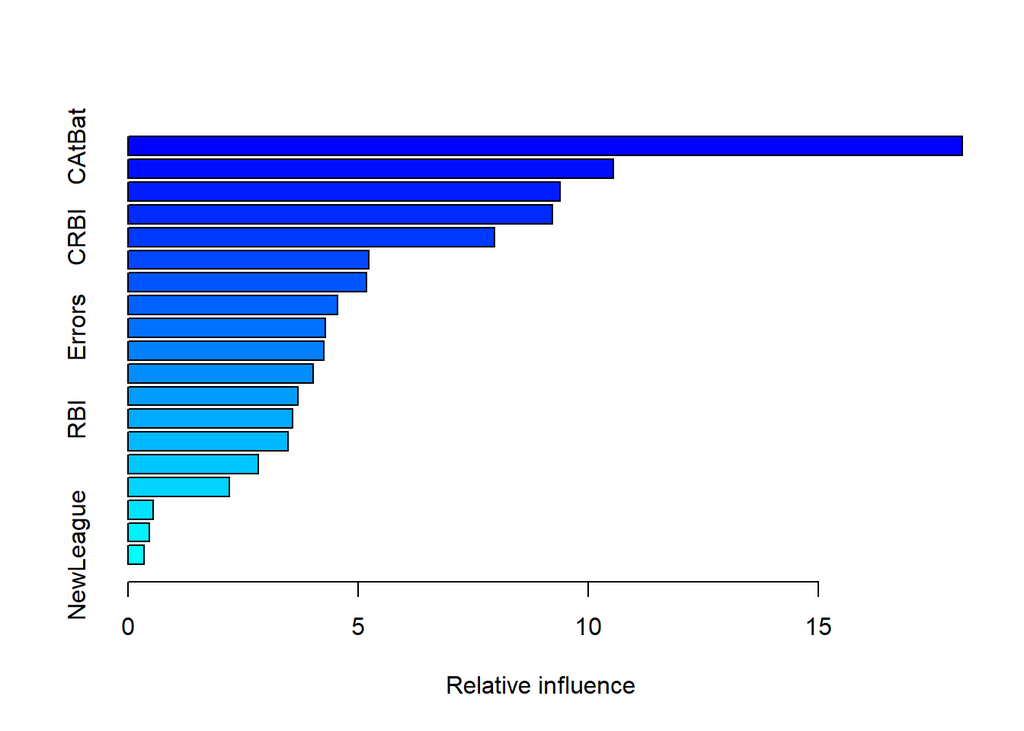

```
##                 var    rel.inf
## CAtBat       CAtBat 18.1333788
## CRuns         CRuns 10.5571533
## CHits         CHits  9.3971138
## CWalks       CWalks  9.2291693
## CRBI           CRBI  7.9748114
## Walks         Walks  5.2407132
## PutOuts     PutOuts  5.1903305
## Hits           Hits  4.5640376
## Errors       Errors  4.2940059
## CHmRun       CHmRun  4.2621136
## Years         Years  4.0179281
## AtBat         AtBat  3.6879027
## RBI             RBI  3.5811795
## HmRun         HmRun  3.4785455
## Assists     Assists  2.8348124
## Runs           Runs  2.1982960
## League       League  0.5507391
## Division   Division  0.4605027
## NewLeague NewLeague  0.3472668
```

```r
boost.best = gbm(Salary~., data=train.set, distribution = "gaussian", n.trees = 1000,
                 interaction.depth = 4, shrinkage = 0.01)
summary(boost.best)
```

##g

```r
bag.Hitters = randomForest(Salary~.,train.set,mtry=16,importance=TRUE)
bag.pred = predict(bag.Hitters,newdata = test.set)
mean((test.set$Salary-bag.pred)^2)
```

```
## [1] 0.1179348
```